# Replication of Pettijohn and Radvansky (2016): Second replication

Sau-Chin Chen, Faber Myrthe

2020/12/04

## Method note

data collection starting time: 2020/12/09 13:00

Participants were native English speakers who are living in the English countries. The changes from the original study: we presented the stories and questions on OSWEB instead of Qualtrics. Participants had the feedback after each comprehension question and checked the latest accuacy at the break and end board.

## Participants

We filtered the participants who did not complete all the stories and finish the post survey. Here is the sample size, averaged age, and percentage of female participants.

```r
## Export participants' background information and post study responses
df %>% select(prolific_participant_id, age, Sex, First.Language) %>% distinct() %>%
    summarise(N = n(), Age = mean(age), `Female %` = mean(Sex=="Female"), `English as First %` = mean(First.Language == "English") )
```

```
##    N      Age  Female % English as First %
## 1 49 27.46939 0.4897959          0.6326531
```

```r
## Check the post survey responses in addition to the debrief
df %>% filter(!is.na(Dimension)) %>%
    filter(Post_Topic %in% c("Cookie", "Honest", "Loading", "Strange") ) %>%
    select(prolific_participant_id, Post_Topic, response) %>%
    group_by(Post_Topic) %>%
    count(response)
```

```
## # A tibble: 7 x 3
## # Groups:   Post_Topic [4]
##   Post_Topic response     n
##   <chr>      <chr>    <int>
## 1 Cookie     f            5
## 2 Cookie     j           44
## 3 Honest     f           49
## 4 Loading    f           45
## 5 Loading    g            4
## 6 Strange    f            4
## 7 Strange    j           45
```

```r
##  Cookie F: Yes,I have set my web browser up to block all cookies (cookies disabeled). J: No, my computer is set up to accept cookies, I do not know.
##  Honest F:YES   J:NO
## Loading F: Yes,the words/sentences loaded quickly and the whole survey ran smoothly.  G: Yes, the words/sentences mostly loaded quickly but there were occasional delays in the survey. H: No, there was a lot of variation in how quickly the words/sentences loaded.  J: No, the survey started out smoothly but the words/sentences loaded more slowly towards the end.
## Strange F:YES   J:NO
```

Among `49` participants, `57.14` % participants accurately answered the debrief.

## Descriptive summary of critical responses

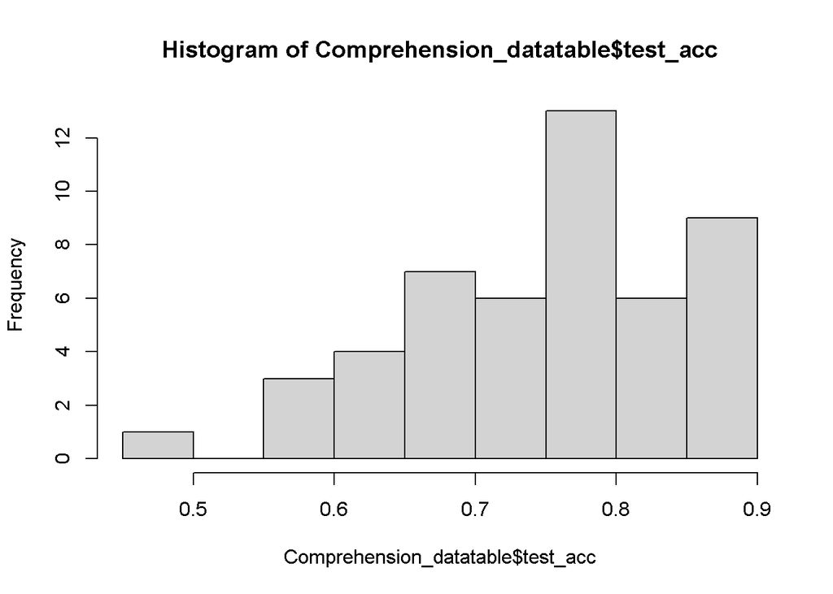

```r
## read comprehension trials by participant
Comprehension_datatable <- df %>% filter(!is.na(Dimension)) %>% ## filter warm-up trials
    filter(probe_type == "q") %>%  ## isolate the comprehension trials
    group_by(prolific_participant_id) %>%
    summarise(test_acc = mean(correct))
hist(Comprehension_datatable$test_acc)
```

Original researchers analyzed data from the participants who passed 75% comprehension questions. `28` participants of this replication accurately answed more than 75% comprehension questions.

```r
## Filter the participants' accuracy below .60
target_id <- subset(Comprehension_datatable, test_acc > .60) %>% pull(prolific_participant_id)

## Count the syllables by lines
Story_df <- df %>% filter(!is.na(Dimension)) %>%
    filter( prolific_participant_id %in% target_id  ) %>%
    filter(probe_type == "n", Dimension != "Filler")

## Count the syllables by sentence
Syls = lapply(Story_df %>% mutate(Syls = sylcount(line_text)) %>% ## isolate the lines
    pull(Syls),  sum) %>%
    unlist()

## Summarize the reading time
ReadingTime_table <- bind_cols(Story_df, Syls)

## Reading time divided by syllables
ReadingTime_df<- ReadingTime_table %>% mutate(reading_time = response_time/Syls ) %>%
    group_by(prolific_participant_id, Dimension, Foreshadow, Shift) %>%
    summarise(subj_reading_time = mean(reading_time) ) %>%
    group_by(Foreshadow, Shift) %>%
    summarise(Average_reading_time = round(mean(subj_reading_time)) )

## Summary of verb responses
Verb_df <- left_join(
(df %>% filter(!is.na(Dimension)) %>% ## filter warm-up trials
    filter( prolific_participant_id %in% target_id  ) %>%
    filter(probe_type == "v") %>%  ## isolate the verb probe responses
    filter(correct == 1) %>%
    group_by(prolific_participant_id, Dimension, Foreshadow, Shift) %>%
    summarise(Verb_rt = mean(response_time,na.rm =TRUE)) %>% as.data.frame() ) %>%
    group_by(Foreshadow, Shift) %>%
    summarise(RT = round(mean(Verb_rt)) ),

(df %>% filter(!is.na(Dimension)) %>% ## filter warm-up trials
    filter( prolific_participant_id %in% target_id  ) %>%
    filter(probe_type == "v") %>%  ## isolate the verb probe responses
##    filter(correct == 1) %>%
    group_by(prolific_participant_id, Dimension, Foreshadow, Shift) %>%
    summarise(Verb_acc = mean(correct)) %>% as.data.frame() ) %>%
    group_by(Foreshadow, Shift) %>%
    summarise(Accuracy = round(mean(Verb_acc),2) ),
by=c("Foreshadow","Shift")
)

##Merge the data summary
Repli_60_df <- left_join(ReadingTime_df, Verb_df, by=c("Foreshadow","Shift"))
```

| Foreshadow | Shift | Average_reading_time | RT | Accuracy |
| --- | --- | --- | --- | --- |
| n | n | 208 | 2307 | 0.76 |
| n | y | 205 | 2101 | 0.73 |
| y | n | 210 | 2044 | 0.77 |
| y | y | 212 | 2074 | 0.76 |

Filtered the participants who had the accuracy below .75, The shortest reading time and verb probe response time occurred at the stories without foreshadow and with shifted event.

```r
## Filter the participants' accuracy below .60
target_id <- subset(Comprehension_datatable, test_acc > .75) %>% pull(prolific_participant_id)

## Count the syllables by lines
Story_df <- df %>% filter(!is.na(Dimension)) %>%
    filter( prolific_participant_id %in% target_id  ) %>%
    filter(probe_type == "n", Dimension != "Filler")

## Count the syllables by sentence
Syls = lapply(Story_df %>% mutate(Syls = sylcount(line_text)) %>% ## isolate the lines
    pull(Syls),  sum) %>%
    unlist()

## Summarize the reading time
ReadingTime_table <- bind_cols(Story_df, Syls)

## Reading time divided by syllables
ReadingTime_df<- ReadingTime_table %>% mutate(reading_time = response_time/Syls ) %>%
    group_by(prolific_participant_id, Dimension, Foreshadow, Shift) %>%
    summarise(subj_reading_time = mean(reading_time) ) %>%
    group_by(Foreshadow, Shift) %>%
    summarise(Average_reading_time = round(mean(subj_reading_time)) )

## Summary of verb responses
Verb_df <- left_join(
(df %>% filter(!is.na(Dimension)) %>% ## filter warm-up trials
    filter( prolific_participant_id %in% target_id  ) %>%
    filter(probe_type == "v") %>%  ## isolate the verb probe responses
    filter(correct == 1) %>%
    group_by(prolific_participant_id, Dimension, Foreshadow, Shift) %>%
    summarise(Verb_rt = mean(response_time,na.rm =TRUE)) %>% as.data.frame() ) %>%
    group_by(Foreshadow, Shift) %>%
    summarise(RT = round(mean(Verb_rt)) ) ,

(df %>% filter(!is.na(Dimension)) %>% ## filter warm-up trials
    filter( prolific_participant_id %in% target_id  ) %>%
    filter(probe_type == "v") %>%  ## isolate the verb probe responses
##    filter(correct == 1) %>%
    group_by(prolific_participant_id, Dimension, Foreshadow, Shift) %>%
    summarise(Verb_acc = mean(correct)) %>% as.data.frame() ) %>%
    group_by(Foreshadow, Shift) %>%
    summarise(Accuracy = round(mean(Verb_acc),2) ),
by=c("Foreshadow","Shift")
)

##Merge the data summary
Repli_75_df <- left_join(ReadingTime_df, Verb_df, by=c("Foreshadow","Shift"))
```

| Foreshadow | Shift | Average_reading_time | RT | Accuracy |
| --- | --- | --- | --- | --- |
| n | n | 225 | 2304 | 0.80 |
| n | y | 198 | 2110 | 0.78 |
| y | n | 223 | 2147 | 0.77 |
| y | y | 221 | 2131 | 0.80 |